# limiares

#### Allegro

0.1 [1] “

"

#### Evolução dos desenvolvedores ao longo do tempo (Desktop Mobile)

( janela 24 semanas, iteracao de 4 semanas) [1] “

"

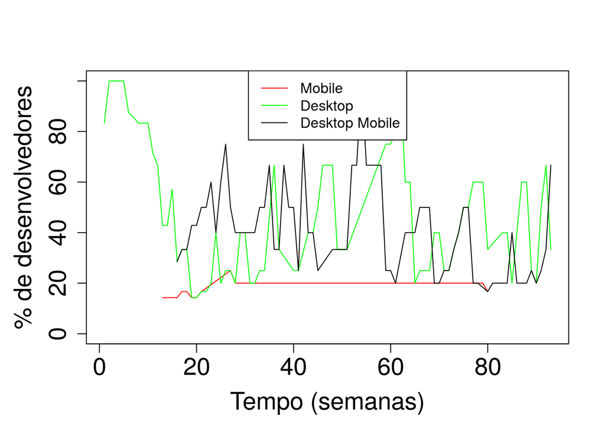

|  | mobile | desktop | mobiledesktop |
| --- | --- | --- | --- |
| twosided | 0.0074055 | 0.1603751 | 0.0002072 |
| greater | 0.0037028 | 0.9198125 | 0.9998964 |
| less | 0.9962972 | 0.0801875 | 0.0001036 |

#### Allegro

0.2 [1] “

"

#### Evolução dos desenvolvedores ao longo do tempo (Desktop Mobile)

( janela 24 semanas, iteracao de 4 semanas) [1] “

"

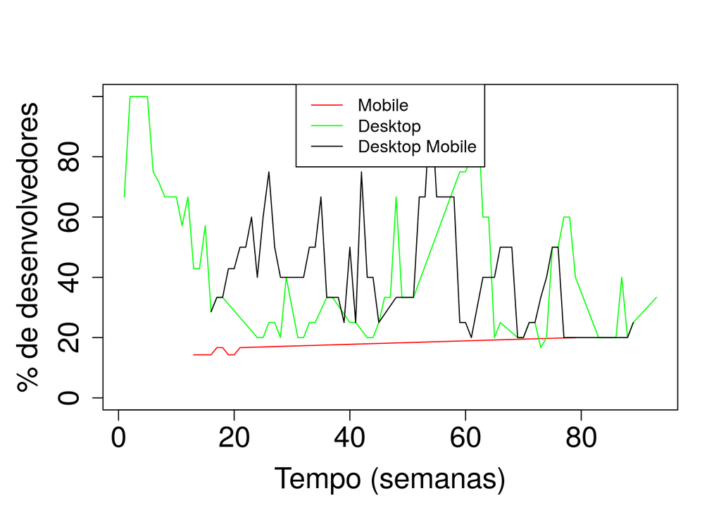

|  | mobile | desktop | mobiledesktop |
| --- | --- | --- | --- |
| twosided | 0.0619696 | 0.0003671 | 0.0071413 |
| greater | 0.0309848 | 0.9998164 | 0.9964293 |
| less | 0.9690152 | 0.0001836 | 0.0035707 |

#### Allegro

0.3 [1] “

"

#### Evolução dos desenvolvedores ao longo do tempo (Desktop Mobile)

( janela 24 semanas, iteracao de 4 semanas) [1] “

"

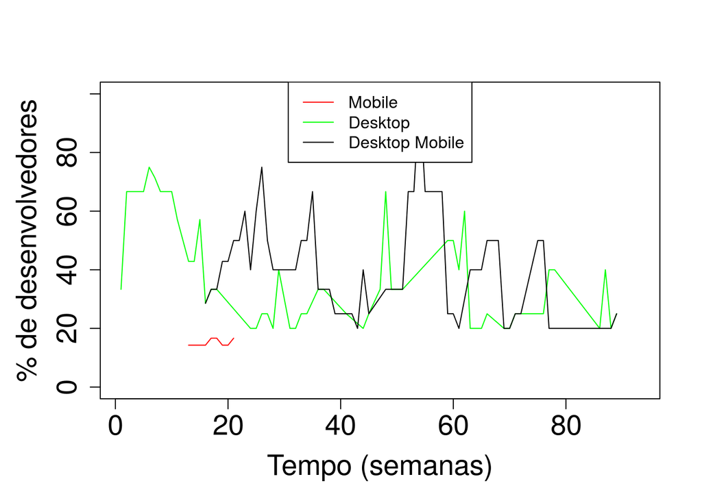

|  | mobile | desktop | mobiledesktop |
| --- | --- | --- | --- |
| twosided | 0.2452781 | 0.000076 | 0.008872 |
| greater | 0.1226391 | 0.999962 | 0.995564 |
| less | 0.8773609 | 0.000038 | 0.004436 |

#### Allegro

0.4 [1] “

"

#### Evolução dos desenvolvedores ao longo do tempo (Desktop Mobile)

( janela 24 semanas, iteracao de 4 semanas) [1] “

"

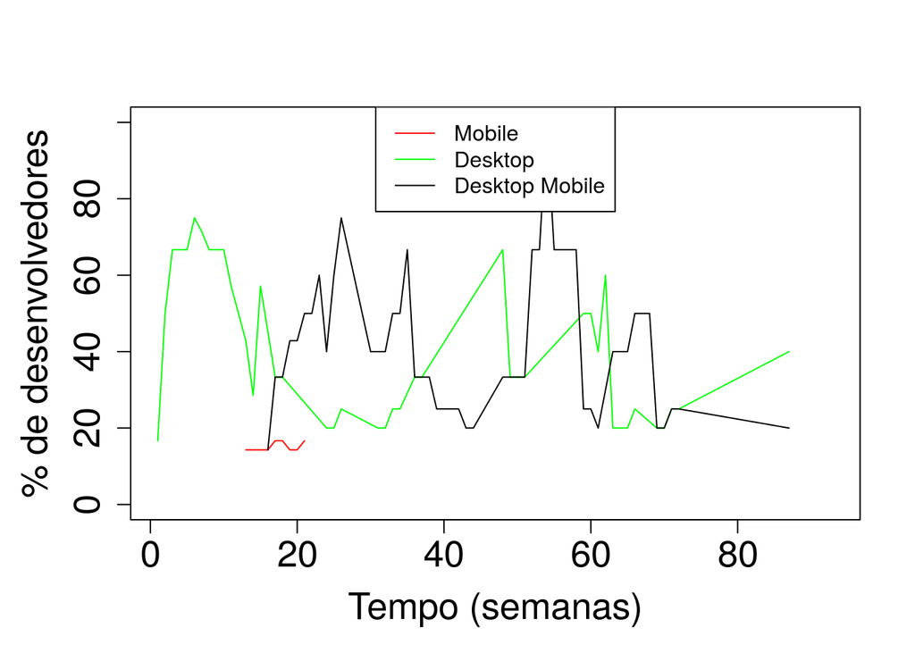

|  | mobile | desktop | mobiledesktop |
| --- | --- | --- | --- |
| twosided | 0.2452781 | 0.0012333 | 0.2061351 |
| greater | 0.1226391 | 0.9993833 | 0.8969324 |
| less | 0.8773609 | 0.0006167 | 0.1030676 |

#### Allegro

0.5 [1] “

"

#### Evolução dos desenvolvedores ao longo do tempo (Desktop Mobile)

( janela 24 semanas, iteracao de 4 semanas) [1] “

"

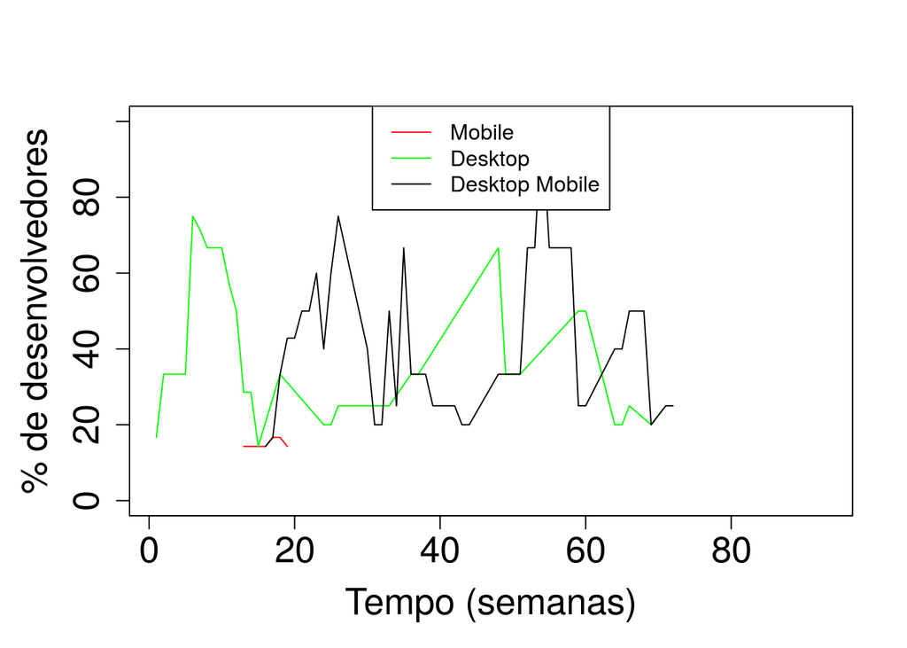

|  | mobile | desktop | mobiledesktop |
| --- | --- | --- | --- |
| twosided | 0.3329216 | 0.0444387 | 0.5780199 |
| greater | 0.1664608 | 0.9777806 | 0.2890099 |
| less | 0.8335392 | 0.0222194 | 0.7109901 |

#### SDL

0.1 [1] “

"

#### Evolução dos desenvolvedores ao longo do tempo (Desktop Mobile)

( janela 24 semanas, iteracao de 4 semanas) [1] “

"

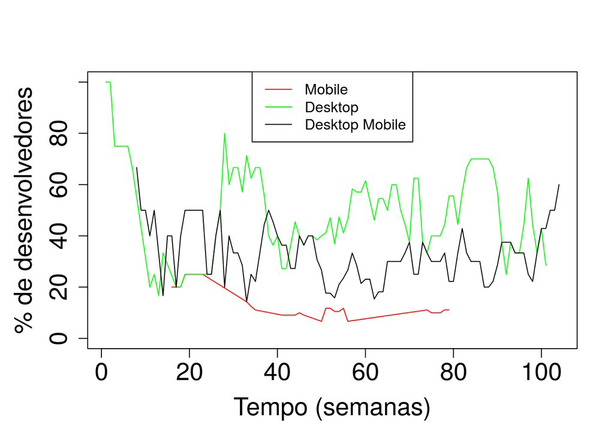

|  | mobile | desktop | mobiledesktop |
| --- | --- | --- | --- |
| twosided | 0.00352 | 0.3918713 | 0.0964963 |
| greater | 0.99824 | 0.1959357 | 0.9517519 |
| less | 0.00176 | 0.8040643 | 0.0482481 |

#### SDL

0.2 [1] “

"

#### Evolução dos desenvolvedores ao longo do tempo (Desktop Mobile)

( janela 24 semanas, iteracao de 4 semanas) [1] “

"

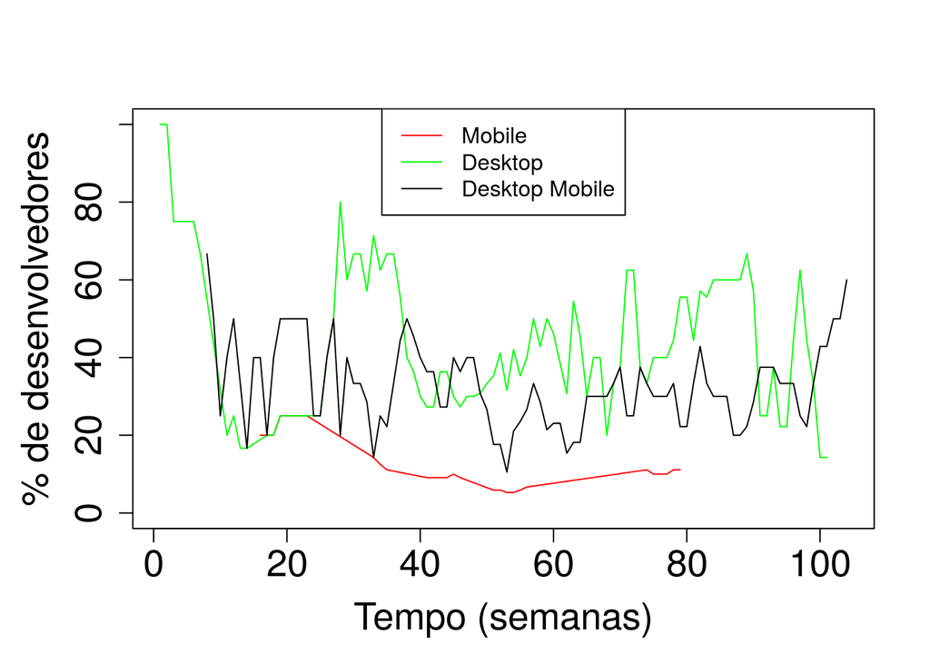

|  | mobile | desktop | mobiledesktop |
| --- | --- | --- | --- |
| twosided | 0.0018787 | 0.6640144 | 0.2038628 |
| greater | 0.9990606 | 0.3320072 | 0.8980686 |
| less | 0.0009394 | 0.6679928 | 0.1019314 |

#### SDL

0.3 [1] “

"

#### Evolução dos desenvolvedores ao longo do tempo (Desktop Mobile)

( janela 24 semanas, iteracao de 4 semanas) [1] “

"

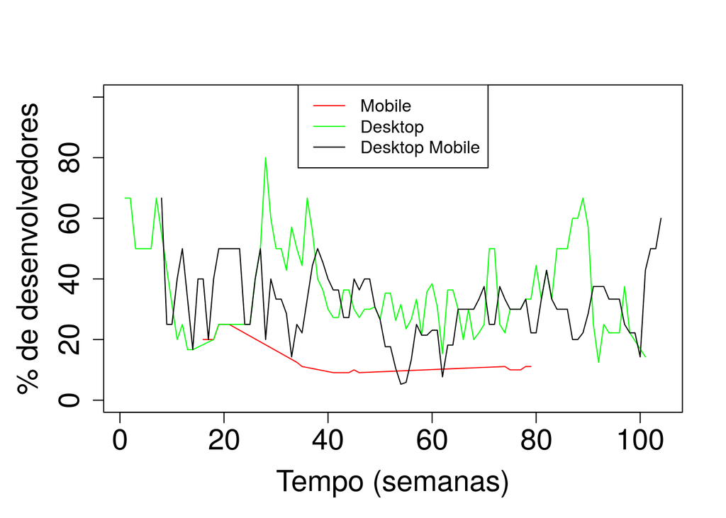

|  | mobile | desktop | mobiledesktop |
| --- | --- | --- | --- |
| twosided | 0.0586354 | 0.081732 | 0.1332430 |
| greater | 0.9706823 | 0.959134 | 0.9333785 |
| less | 0.0293177 | 0.040866 | 0.0666215 |

#### SDL

0.4 [1] “

"

#### Evolução dos desenvolvedores ao longo do tempo (Desktop Mobile)

( janela 24 semanas, iteracao de 4 semanas) [1] “

"

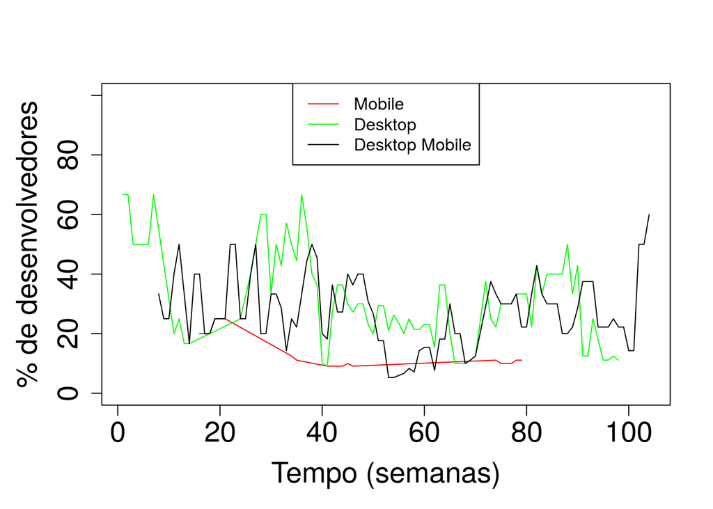

|  | mobile | desktop | mobiledesktop |
| --- | --- | --- | --- |
| twosided | 0.0586354 | 0.000296 | 0.3355477 |
| greater | 0.9706823 | 0.999852 | 0.8322262 |
| less | 0.0293177 | 0.000148 | 0.1677738 |

#### SDL

0.5 [1] “

"

#### Evolução dos desenvolvedores ao longo do tempo (Desktop Mobile)

( janela 24 semanas, iteracao de 4 semanas) [1] “

"

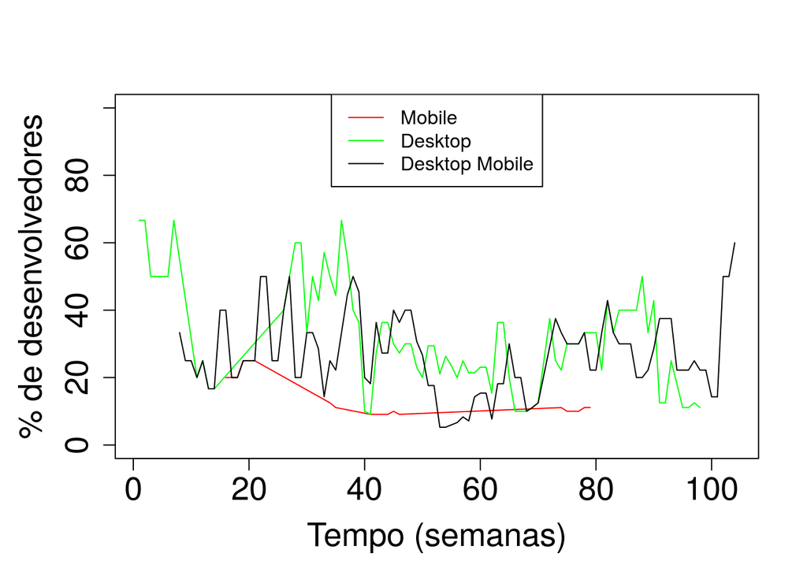

|  | mobile | desktop | mobiledesktop |
| --- | --- | --- | --- |
| twosided | 0.0586354 | 0.0001906 | 0.9139190 |
| greater | 0.9706823 | 0.9999047 | 0.5430405 |
| less | 0.0293177 | 0.0000953 | 0.4569595 |

#### SFML

0.1 [1] “

"

#### Evolução dos desenvolvedores ao longo do tempo (Desktop Mobile)

( janela 24 semanas, iteracao de 4 semanas) [1] “

"

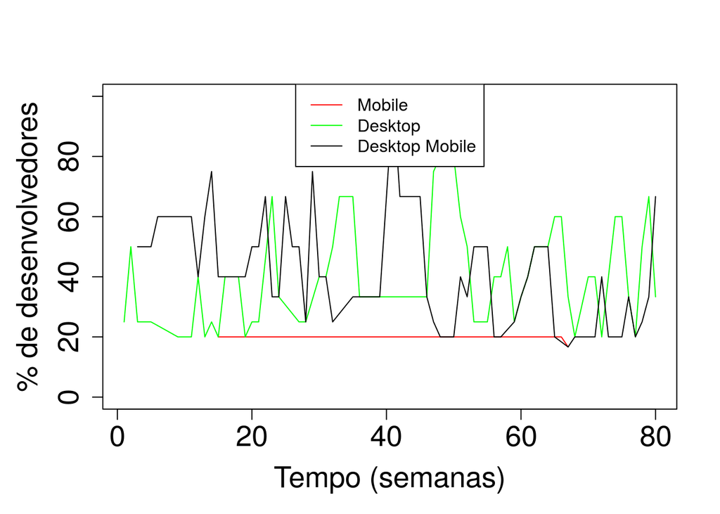

|  | mobile | desktop | mobiledesktop |
| --- | --- | --- | --- |
| twosided | 0.2888444 | 0.0087364 | 0.0000067 |
| greater | 0.8555778 | 0.0043682 | 0.9999966 |
| less | 0.1444222 | 0.9956318 | 0.0000034 |

#### SFML

0.2 [1] “

"

#### Evolução dos desenvolvedores ao longo do tempo (Desktop Mobile)

( janela 24 semanas, iteracao de 4 semanas) [1] “

"

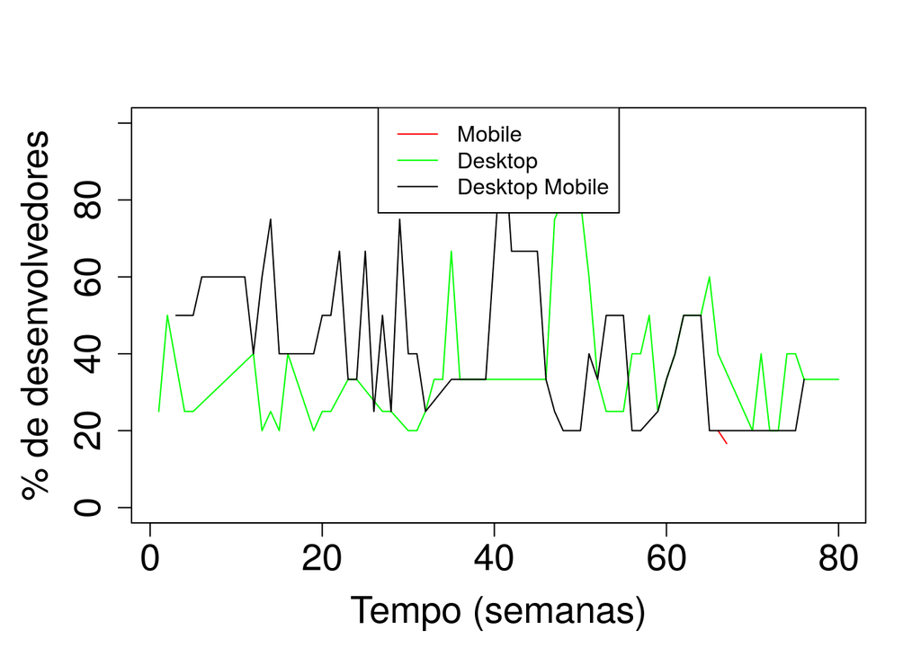

|  | mobile | desktop | mobiledesktop |
| --- | --- | --- | --- |
| twosided | 99 | 0.0284959 | 0.0004069 |
| greater | 99 | 0.0142480 | 0.9997966 |
| less | 99 | 0.9857520 | 0.0002034 |

#### SFML

0.3 [1] “

"

#### Evolução dos desenvolvedores ao longo do tempo (Desktop Mobile)

( janela 24 semanas, iteracao de 4 semanas) [1] “

"

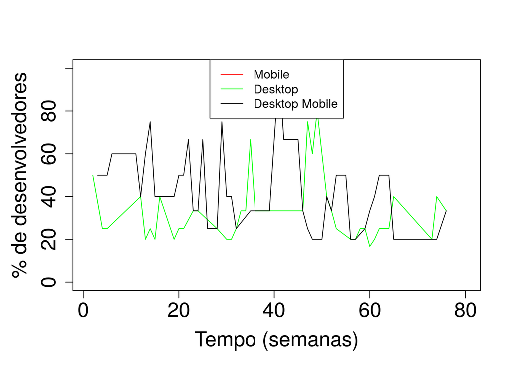

|  | mobile | desktop | mobiledesktop |
| --- | --- | --- | --- |
| twosided | 99 | 0.9279511 | 0.0013394 |
| greater | 99 | 0.4639756 | 0.9993303 |
| less | 99 | 0.5360244 | 0.0006697 |

#### SFML

0.4 [1] “

"

#### Evolução dos desenvolvedores ao longo do tempo (Desktop Mobile)

( janela 24 semanas, iteracao de 4 semanas) [1] “

"

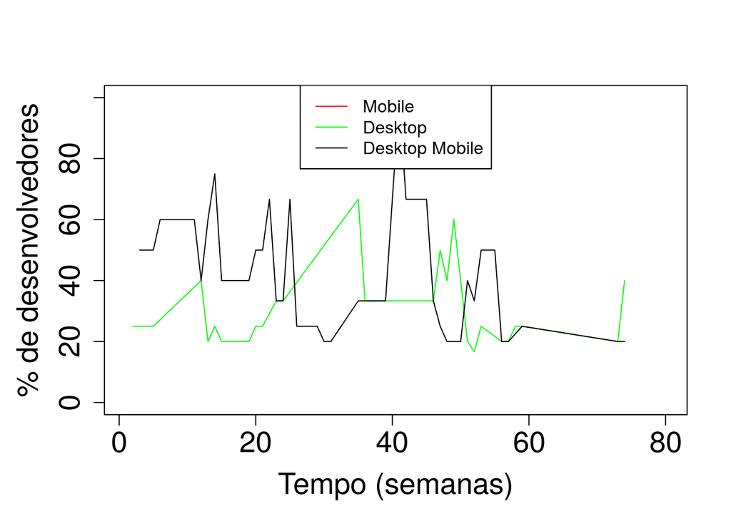

|  | mobile | desktop | mobiledesktop |
| --- | --- | --- | --- |
| twosided | 99 | 0.7797083 | 0.0030131 |
| greater | 99 | 0.3898541 | 0.9984935 |
| less | 99 | 0.6101459 | 0.0015065 |

#### SFML

0.5 [1] “

"

#### Evolução dos desenvolvedores ao longo do tempo (Desktop Mobile)

( janela 24 semanas, iteracao de 4 semanas) [1] “

"

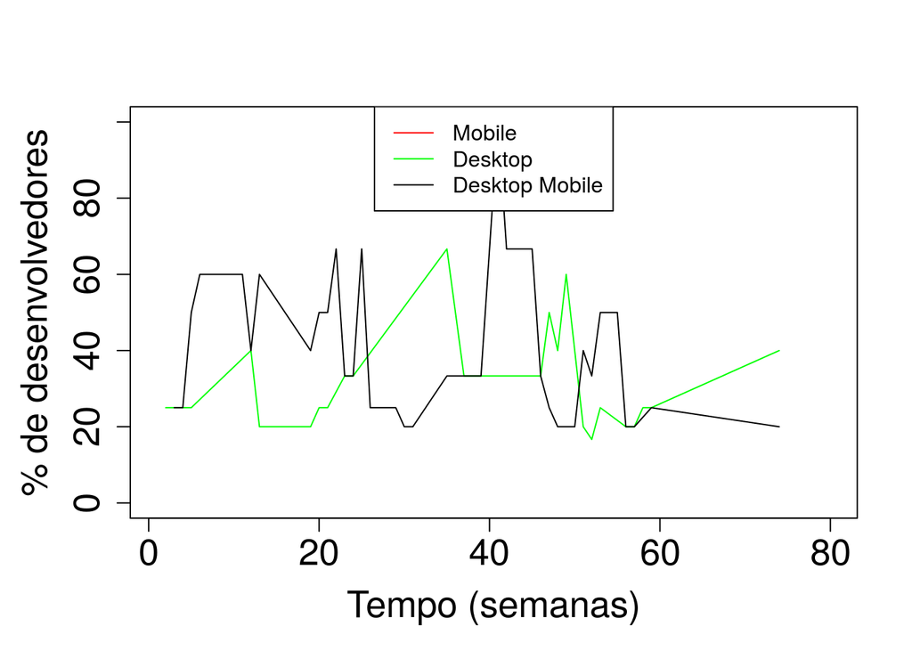

|  | mobile | desktop | mobiledesktop |
| --- | --- | --- | --- |
| twosided | 99 | 0.8922050 | 0.0645965 |
| greater | 99 | 0.4461025 | 0.9677017 |
| less | 99 | 0.5538975 | 0.0322983 |

#### Coco2dx

0.1 [1] “

"

#### Evolução dos desenvolvedores ao longo do tempo (Desktop Mobile)

( janela 24 semanas, iteracao de 4 semanas) [1] “

"

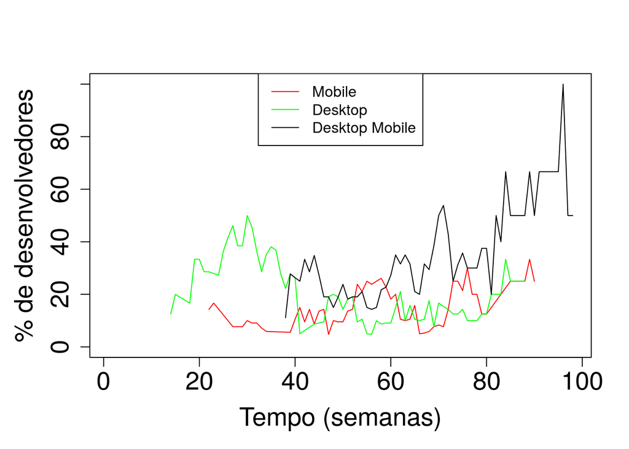

|  | mobile | desktop | mobiledesktop |
| --- | --- | --- | --- |
| twosided | 0.0001090 | 0.00128 | 0 |
| greater | 0.0000545 | 0.99936 | 0 |
| less | 0.9999455 | 0.00064 | 1 |

#### Coco2dx

0.2 [1] “

"

#### Evolução dos desenvolvedores ao longo do tempo (Desktop Mobile)

( janela 24 semanas, iteracao de 4 semanas) [1] “

"

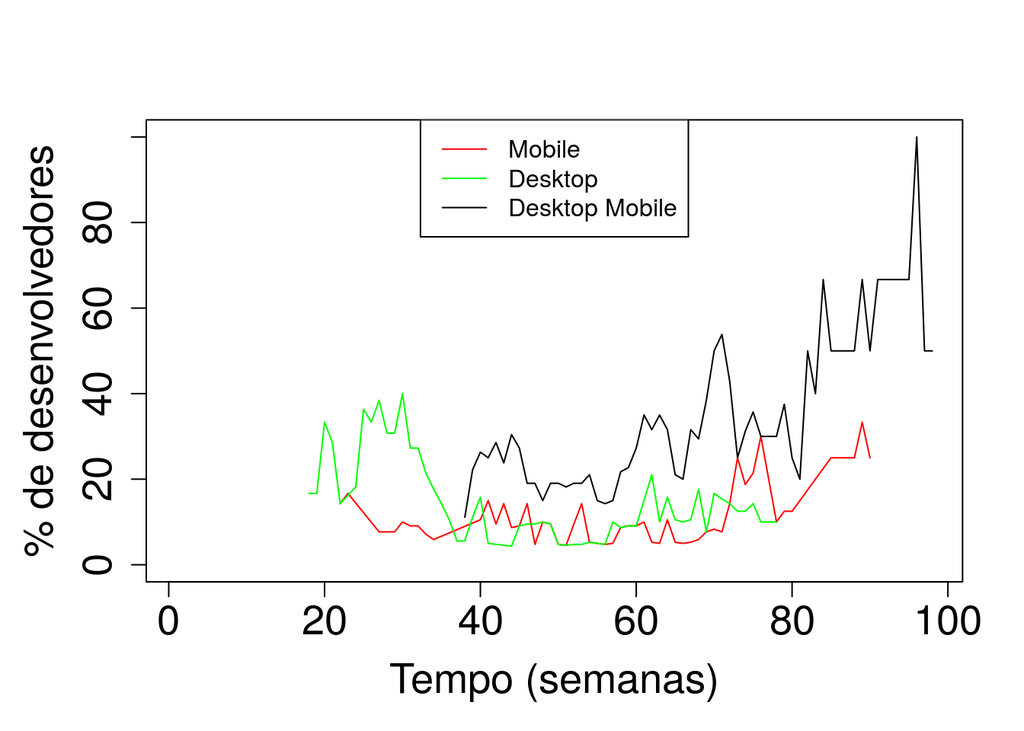

|  | mobile | desktop | mobiledesktop |
| --- | --- | --- | --- |
| twosided | 0.0040845 | 0.0067596 | 0 |
| greater | 0.0020422 | 0.9966202 | 0 |
| less | 0.9979578 | 0.0033798 | 1 |

#### Coco2dx

0.3 [1] “

"

#### Evolução dos desenvolvedores ao longo do tempo (Desktop Mobile)

( janela 24 semanas, iteracao de 4 semanas) [1] “

"

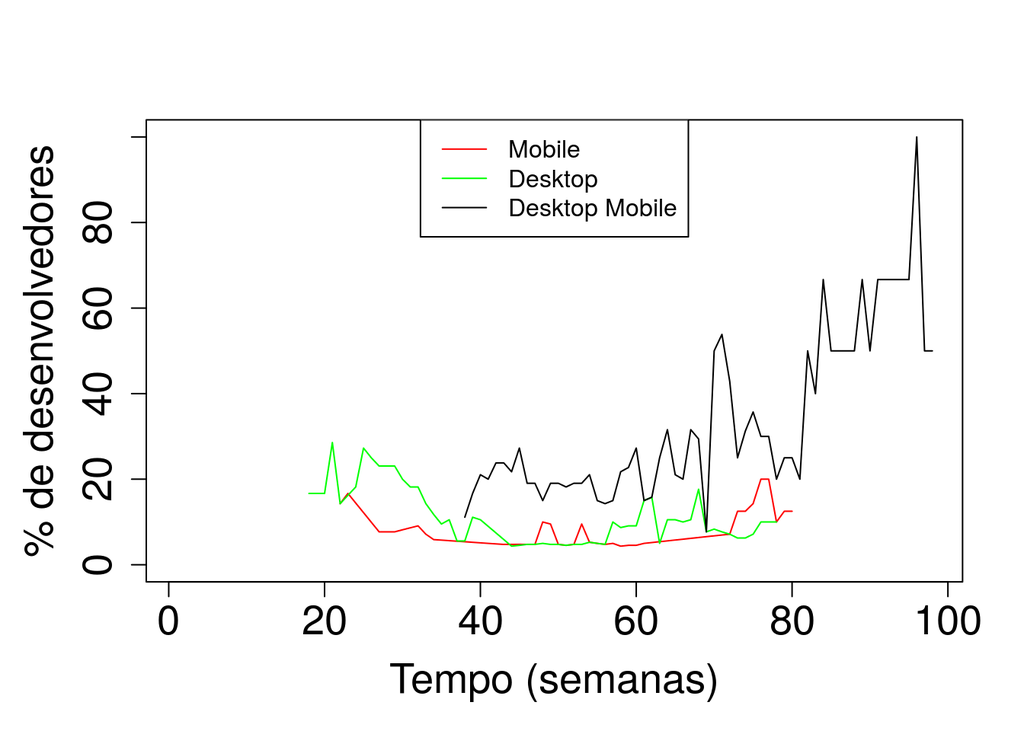

|  | mobile | desktop | mobiledesktop |
| --- | --- | --- | --- |
| twosided | 0.5485198 | 0.0014679 | 0 |
| greater | 0.2742599 | 0.9992660 | 0 |
| less | 0.7257401 | 0.0007340 | 1 |

#### Coco2dx

0.4 [1] “

"

#### Evolução dos desenvolvedores ao longo do tempo (Desktop Mobile)

( janela 24 semanas, iteracao de 4 semanas) [1] “

"

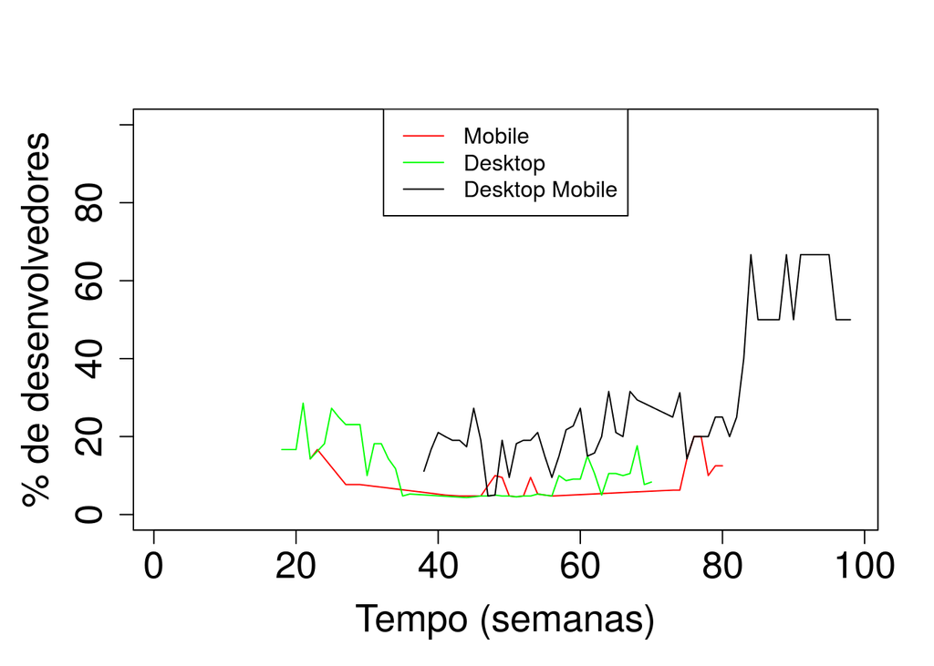

|  | mobile | desktop | mobiledesktop |
| --- | --- | --- | --- |
| twosided | 0.3116171 | 0.0263465 | 0 |
| greater | 0.1558085 | 0.9868267 | 0 |
| less | 0.8441915 | 0.0131733 | 1 |

#### Coco2dx

0.5 [1] “

"

#### Evolução dos desenvolvedores ao longo do tempo (Desktop Mobile)

( janela 24 semanas, iteracao de 4 semanas) [1] “

"

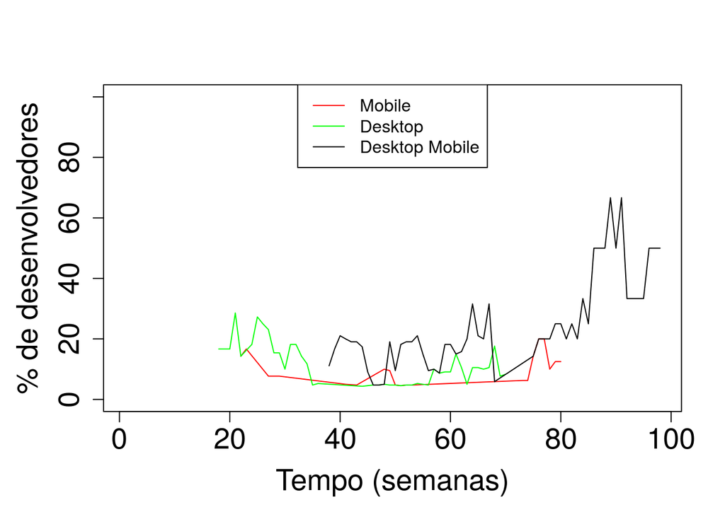

|  | mobile | desktop | mobiledesktop |
| --- | --- | --- | --- |
| twosided | 0.4838750 | 0.0226232 | 0 |
| greater | 0.2419375 | 0.9886884 | 0 |
| less | 0.7580625 | 0.0113116 | 1 |

#### Godot

0.1 [1] “

"

#### Evolução dos desenvolvedores ao longo do tempo (Desktop Mobile)

( janela 24 semanas, iteracao de 4 semanas) [1] “

"

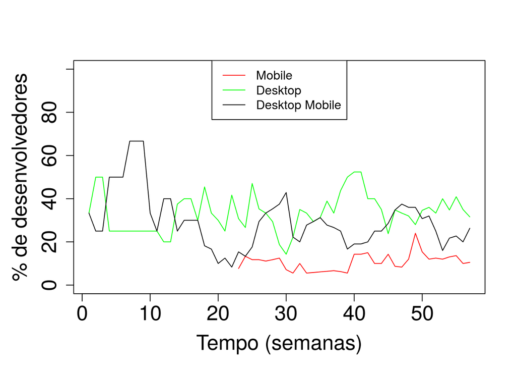

|  | mobile | desktop | mobiledesktop |
| --- | --- | --- | --- |
| twosided | 0.1431467 | 0.1686032 | 0.0560128 |
| greater | 0.0715734 | 0.0843016 | 0.9719936 |
| less | 0.9284266 | 0.9156984 | 0.0280064 |

#### Godot

0.2 [1] “

"

#### Evolução dos desenvolvedores ao longo do tempo (Desktop Mobile)

( janela 24 semanas, iteracao de 4 semanas) [1] “

"

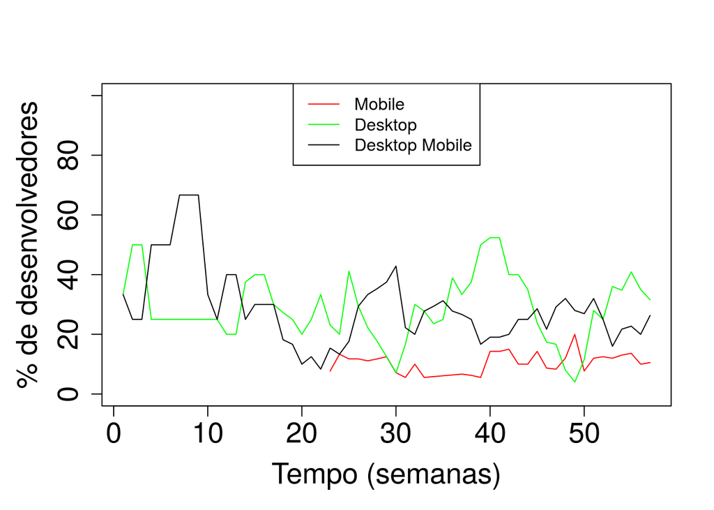

|  | mobile | desktop | mobiledesktop |
| --- | --- | --- | --- |
| twosided | 0.2479993 | 0.8535321 | 0.0109086 |
| greater | 0.1239996 | 0.5732339 | 0.9945457 |
| less | 0.8760004 | 0.4267661 | 0.0054543 |

#### Godot

0.3 [1] “

"

#### Evolução dos desenvolvedores ao longo do tempo (Desktop Mobile)

( janela 24 semanas, iteracao de 4 semanas) [1] “

"

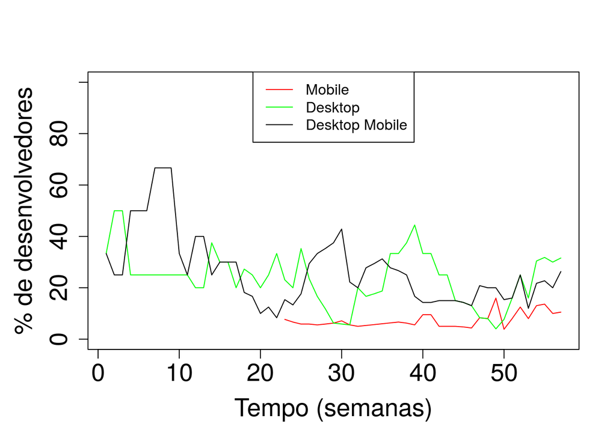

|  | mobile | desktop | mobiledesktop |
| --- | --- | --- | --- |
| twosided | 0.0819753 | 0.0233345 | 0.0000981 |
| greater | 0.0409876 | 0.9883328 | 0.9999510 |
| less | 0.9590124 | 0.0116672 | 0.0000490 |

#### Godot

0.4 [1] “

"

#### Evolução dos desenvolvedores ao longo do tempo (Desktop Mobile)

( janela 24 semanas, iteracao de 4 semanas) [1] “

"

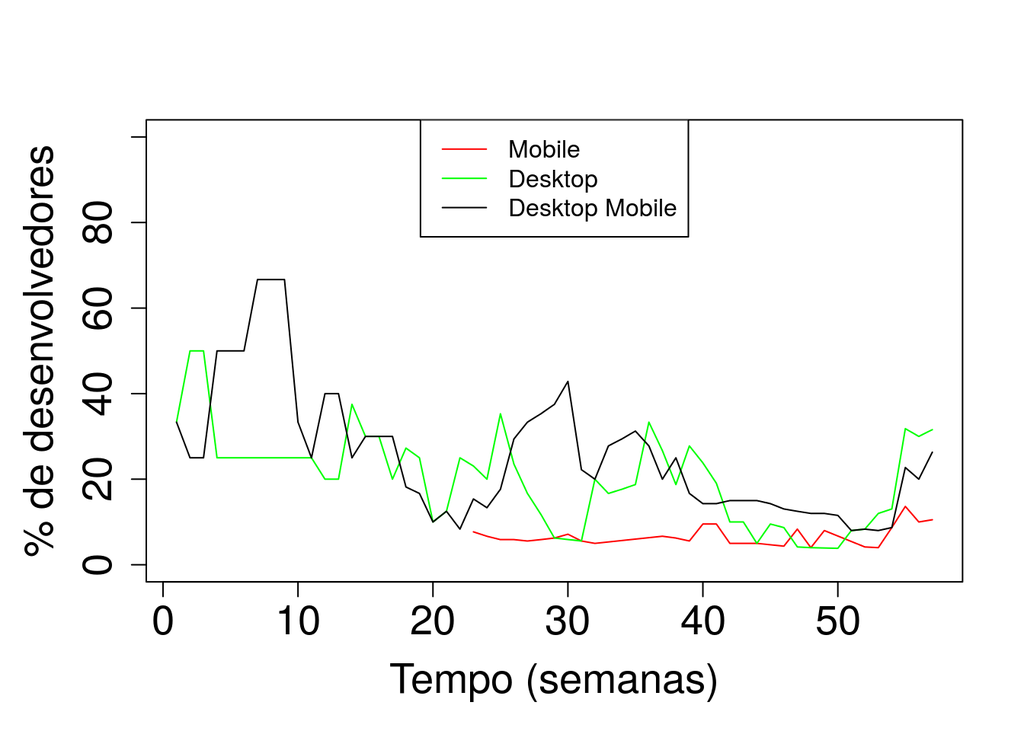

|  | mobile | desktop | mobiledesktop |
| --- | --- | --- | --- |
| twosided | 0.8895777 | 0.0001110 | 1e-07 |
| greater | 0.4447888 | 0.9999445 | 1e+00 |
| less | 0.5552112 | 0.0000555 | 0e+00 |

#### Godot

0.5 [1] “

"

#### Evolução dos desenvolvedores ao longo do tempo (Desktop Mobile)

( janela 24 semanas, iteracao de 4 semanas) [1] “

"

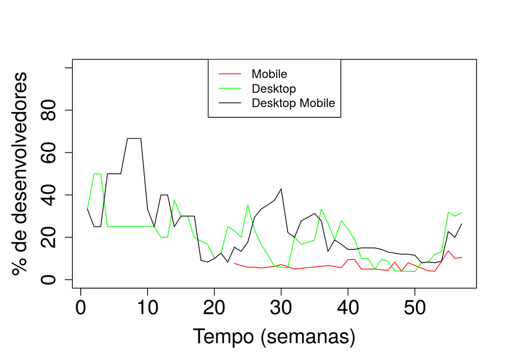

|  | mobile | desktop | mobiledesktop |
| --- | --- | --- | --- |
| twosided | 0.8017287 | 0.0001947 | 0.0000011 |
| greater | 0.4008643 | 0.9999026 | 0.9999994 |
| less | 0.5991357 | 0.0000974 | 0.0000006 |